# Homework 6

Author: Matthew J. Cossley

Last update: 25 April, 2022

## 0.

- Create a new file named `cogs2020_hw_6.R` and save it in the `cogs2020` folder that you created during Lecture 1.
- If you have not already installed the `data.table` and the `ggplot2` packages, do so now. If you use the `install.packages` function, do not include it in the script that you hand in.
- Make the first line of your script `library(data.table)` and the second line `library(ggplot2)`.
- Make the second line of your script `rm(list=ls())`. This line of code will erase any variable defined before it. Do not put this line of code after anything important that you want to keep (e.g., so that I can mark your work).
- After `rm(list=ls())`, create a variable named `my_name` and set its value equal to a **character** vector (i.e., letters surrounded by `""` or by `''`) containing your name.
- After `rm(list=ls())`, create a variable named `my_student_id` and set its value equal to a **character** vector (i.e., letters surrounded by `""` or by `''`) containing your student id.
- So far, here is what your file should look like if your name is `John Doe` and and your student ID is `12345678`. Note that the following code chunk also includes a few lines to create a `data.table` named `d` that many of the problems below require you manipulate.

```r
# load the packages we will need
library(data.table)
library(ggplot2)

# clean session
rm(list=ls())

# basic id info
my_name <- "John Doe"
my_student_id <- "12345678"

# Please include the following line of code as well
set.seed(0)
```

** NOTE: This problem set is mostly the same as the previous problem set but with one-tailed tests replaced with two-tailed tests.**

## 1.

Suppose that researchers for a popular social media platform are interested maximising the amount of time that users spend on their app, and that they are faced with a tough decision about whether or not the app should use a continuous scroll feature. Since opinions on the research team are split on the issue, they decide to perform an experiment to clear things up. They implement the continuous scroll feature and push it to their users. The average time that a user spends on app currently is 58 minutes per day. Thus they are interested in whether or not continuous scroll increases this number. Suppose they obtain the following sample from this experiment:

$$x = \{ 63.97, 60.29, 85.60, 72.57, 54.65, 53.74, 69.13, 70.07, 67.19, 53.95 \}$$

Test the hypothesis that infinite scroll had any effect whatsoever (increased or decreased) time on app beyond 58 minutes per day assuming that the population variance of $X$ is $\sigma_X^2 = 10$. **Do not use `t.test`, `binim.test` or any other built in full test function unless explicitly instructed to do so.**

- Store the value of your observed test statistic in a variable named `ans_1_test_stat_obs`.
- Store the lower critical value of your test in a variable named `ans_1_critical_value_lower`.
- Store the upper critical value of your test in a variable named `ans_1_critical_value_upper`.
- Store the lower bound of a 95% CI for your test statistic in a variable named `ans_1_CI_lower`.
- Store the upper bound of a 95% CI for your test statistic in a variable named `ans_1_CI_upper`.
- Store the p-value of your test in a variable named `ans_1_p_value`.

## 2.

Suppose that a cognitive neuroscientist would like to discover if the response a participant makes in a 2-alternative forced choice task can be predicted on the basis of neural activity occurring 1 second before the motor response is made. They train a machine learning classifier to do this, and discover that it correctly predicts participant choices in 63 out of 100 trials. Test the hypothesis that their machine learning classifier predicts participant choice at levels significantly different from chance (i.e., above chance or below chance). **Do not use `t.test`, `binim.test` or any other built in full test function unless explicitly instructed to do so.**

- Store the value of your observed test statistic in a variable named `ans_2_test_stat_obs`.
- Store the lower critical value of your test in a variable named `ans_2_critical_value_lower`.
- Store the upper critical value of your test in a variable named `ans_2_critical_value_upper`.
- Store the lower bound of a 95% CI for your test statistic in a variable named `ans_2_CI_lower`.
- Store the upper bound of a 95% CI for your test statistic in a variable named `ans_2_CI_upper`.
- Store the p-value of your test in a variable named `ans_2_p_value`.

## 3.

Test the hypothesis that $\theta$ is different than 0.5, where $\theta$ is a parameter of some random variable. The sampling distribution for $\hat{\theta}$ is shown in the following figure and the observed test statistic $\hat{\theta}_{obs}$ is shown in blue. Ensure that the type I error rate of your test is $\alpha=0.05$.

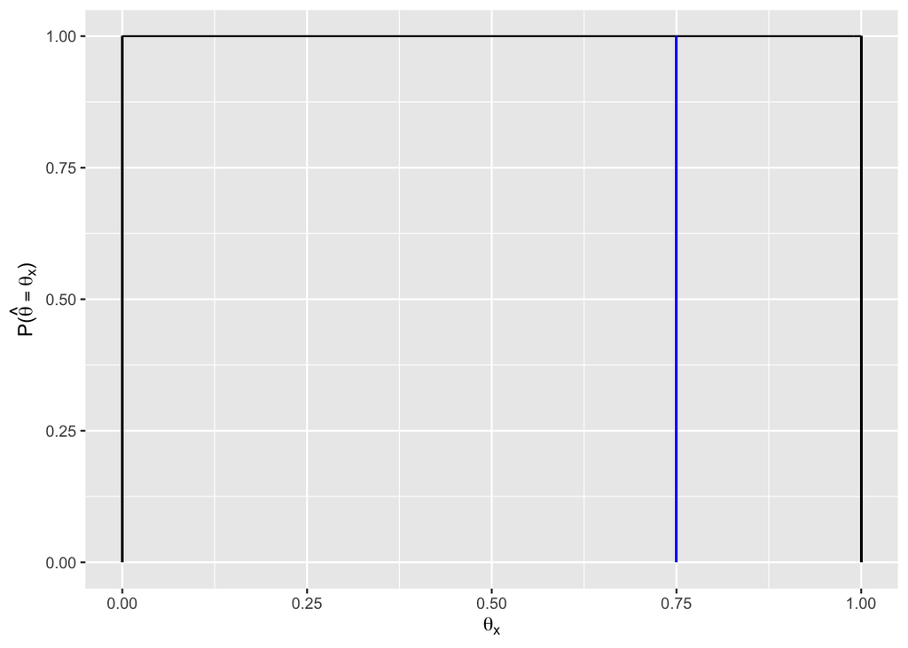

- Store the lower critical value of your test in a variable named `ans_3_critical_value_lower`.
- Store the upper critical value of your test in a variable named `ans_3_critical_value_upper`.
- Store the lower bound of a 95% CI for $\hat{\theta}$ in a variable named `ans_3_CI_lower`.
- Store the upper bound of a 95% CI for $\hat{\theta}$ in a variable named `ans_3_CI_upper`.
- Store the p-value of this test in a variable named `ans_3_p_value`.

## 4.

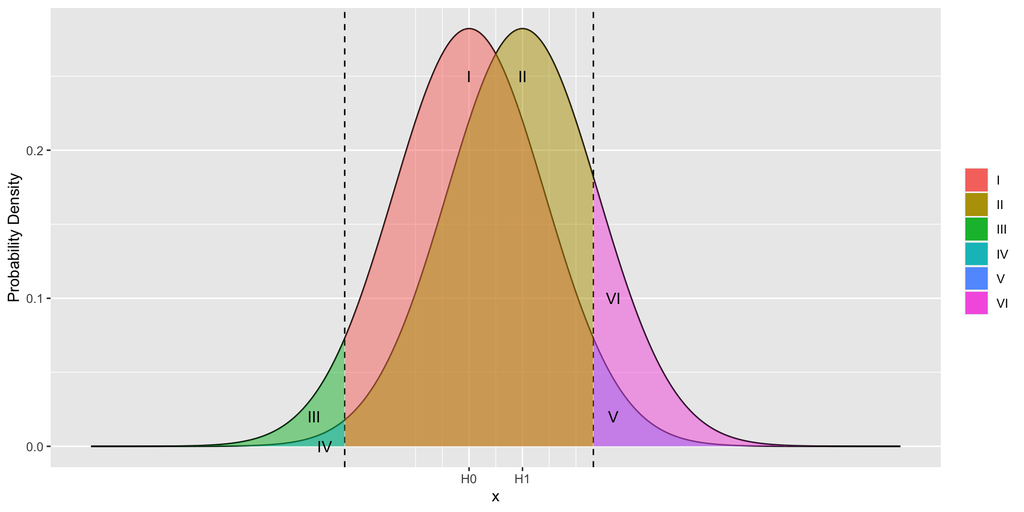

Please respond by assigning `"confidence"`, `"alpha"`, `"beta"`, or `"power"` to the variables requested below. Note that the dashed lines in the above figure are the critical values.

- What quantity does region I in the above plot contribute to? Store your answer in a variable named `ans_4a`.
- What quantity does region II in the above plot contribute to? Store your answer in a variable named `ans_4b`.
- What quantity does region III in the above plot contribute to? Store your answer in a variable named `ans_4c`.
- What quantity does region IV in the above plot contribute to? Store your answer in a variable named `ans_4d`.
- What quantity does region V in the above plot contribute to? Store your answer in a variable named `ans_4e`.
- What quantity does region VI in the above plot contribute to? Store your answer in a variable named `ans_4f`.

## Final Check

A common error on these problem sets is to accidentally erase or overwrite variables from one question with those from another. Another common error is to name your variables slightly wrong (e.g., `Ans_1a` instead of `ans_1a`). Yet another common error is to include a line of code or two that generates an error, and sometimes this error is serious enough to prevent most or all of your script from running, in which case you will lose most or all of your marks for that assignment. All of these can be a very frustrating way to lose marks, but you will indeed lose marks if you make these mistakes, so you need to be very careful!

To ensure that this doesn’t happen to you, please run your entire `.R` script from start to finish. One way to do this is to use `Code > Run Region > Run All`, but of course there are shortcuts for everything so do as you wish. If there are any errors at all when you do this, it is essential that you address them.

After all of your code has executed from start to finish without and errors at all, then carefully inspect your workspace to ensure that the following variables are defined. A reasonable way to do this is to try to print each one of these variables to the console. If it is defined, then it will print without error.

```r
my_name
my_student_id
ans_1_test_stat_obs
ans_1_critical_value_lower
ans_1_critical_value_upper
ans_1_CI_lower
ans_1_CI_upper
ans_1_p_value
ans_2_test_stat_obs
ans_2_critical_value_lower
ans_2_critical_value_upper
ans_2_CI_lower
ans_2_CI_upper
ans_2_p_value
ans_3_critical_value_lower
ans_3_critical_value_upper
ans_3_CI_lower
ans_3_CI_upper
ans_3_p_value
ans_4a
ans_4b
ans_4c
ans_4d
ans_4e
ans_4f
```

Finally, be sure that the file you submit to iLearn is a `.R` file and nothing else. Any other extension cannot be marked. This means do not submit `.Rmd`, `.RProj`, `.pdf`, `.html` or anything else. You must submit a `.R` file.